# PA1_template

ZHU Quanming

2023-05-03

## Data

The data for this assignment can be downloaded from the course web site:

- Dataset: [Activity monitoring data](https://d396qusza40orc.cloudfront.net/repdata%2Fdata%2Factivity.zip) [52K]

The variables included in this dataset are:

- **steps**: Number of steps taking in a 5-minute interval (missing values are coded as `NA`)
- **date**: The date on which the measurement was taken in YYYY-MM-DD format
- **interval**: Identifier for the 5-minute interval in which measurement was taken

The dataset is stored in a comma-separated-value (CSV) file and there are a total of 17,568 observations in this dataset.

## Assignment

```r
# config the library
library("dplyr")
library("lubridate")
library("ggplot2")
```

### 1. Loading and preprocessing the data

1. Load the data (i.e. `read.csv()`)

```r
datafile <- "activity.csv"
df <- read.csv(datafile)
```

```r
# basic information check
# Dimension info
dim(df)
```

```
## [1] 17568     3
```

```r
# First 10 line
head(df)
```

```
##   steps       date interval
## 1    NA 2012-10-01        0
## 2    NA 2012-10-01        5
## 3    NA 2012-10-01       10
## 4    NA 2012-10-01       15
## 5    NA 2012-10-01       20
## 6    NA 2012-10-01       25
```

```r
# field info
str(df)
```

```
## 'data.frame':    17568 obs. of  3 variables:
##  $ steps   : int  NA NA NA NA NA NA NA NA NA NA ...
##  $ date    : chr  "2012-10-01" "2012-10-01" "2012-10-01" "2012-10-01" ...
##  $ interval: int  0 5 10 15 20 25 30 35 40 45 ...
```

```r
# sumary of data frame
summary(df)
```

```
##      steps            date              interval
##  Min.   :  0.00   Length:17568       Min.   :   0.0
##  1st Qu.:  0.00   Class :character   1st Qu.: 588.8
##  Median :  0.00   Mode  :character   Median :1177.5
##  Mean   : 37.38                      Mean   :1177.5
##  3rd Qu.: 12.00                      3rd Qu.:1766.2
##  Max.   :806.00                      Max.   :2355.0
##  NA's   :2304
```

2. Process/transform the data (if necessary) into a format suitable for your analysis

```r
df <- df %>%
    mutate(date = as.Date(date))# convert chr date to Date format
    # mutate(weekday = wday(date,week_start = getOption("lubridate.week.start", 1)))
```

### 2. What is mean total number of steps taken per day?

For this part of the assignment, you can ignore the missing values in the dataset.

1. Calculate the total number of steps taken per day

```r
as21 <- df %>%
    group_by(date) %>%
    summarise(steps.total.daily=sum(steps,na.rm=TRUE))
    # ungroup() %>%
    # filter(daily.steps>0)
```

2. If you do not understand the difference between a histogram and a barplot, research the difference between them. Make a histogram of the total number of steps taken each day

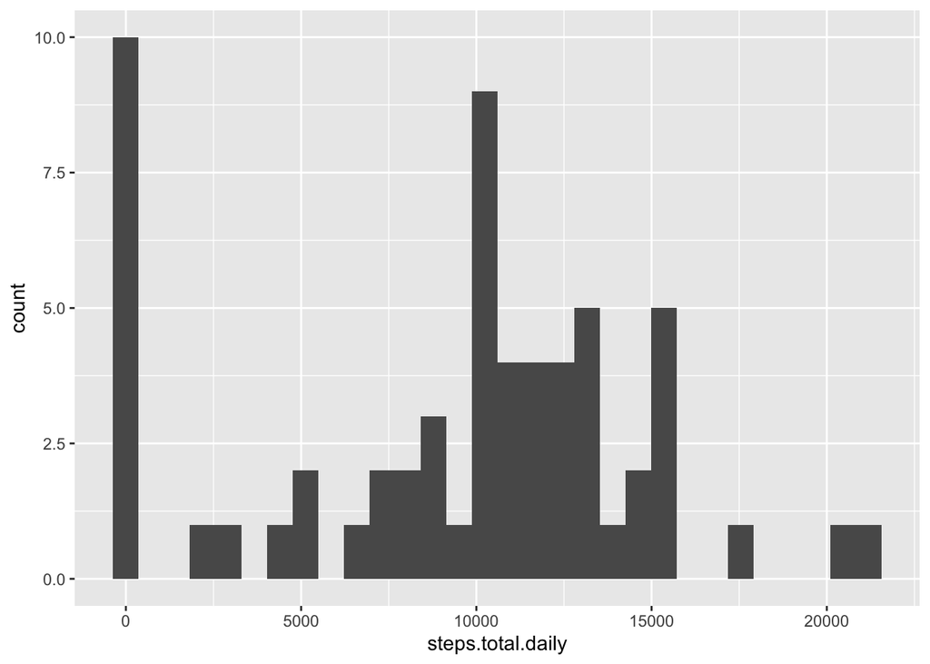

```r
as22g <- ggplot(as21,aes(x=steps.total.daily))+
    geom_histogram()

print(as22g)
```

3. Calculate and report the mean and median of the total number of steps taken per day

```r
# data cleaning prep
as23d <- df %>%
    group_by(date) %>%
    summarise(steps.total.daily=sum(steps,na.rm=TRUE))
```

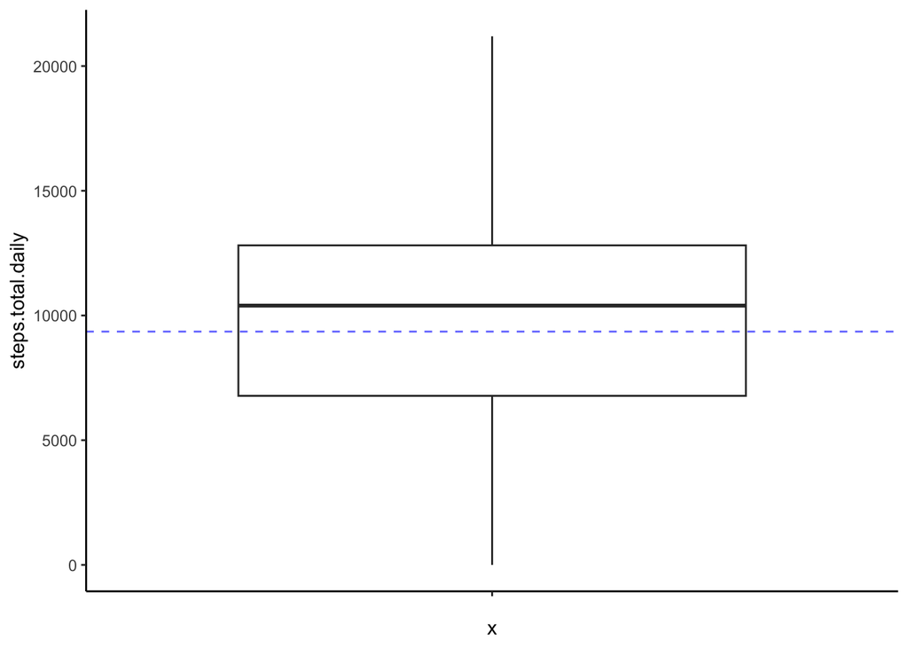

```r
# Show mean with blue dash line and median with black solide line in box
as23g <-
    ggplot(as23d,aes(x="",y=steps.total.daily)) +
    geom_boxplot() +
    geom_hline(yintercept=mean(as23d$steps.total.daily),
               color="blue",
               linetype="dashed",
               linewidth=.5,
               alpha=0.618,
               ) +
    theme_classic()

print(as23g)
```

### 3.What is the average daily activity pattern?

1. Make a time series plot (i.e. `type = "l"`) of the 5-minute interval (x-axis) and the average number of steps taken, averaged across all days (y-axis)

```r
# data cleaning prep
# average steps per days

as31d <- df %>%
    filter(!is.na(steps)) %>%
    filter(steps>0) %>%
    group_by(interval) %>%
    summarise(mean.step.interval=mean(steps)) %>%
    ungroup()
```

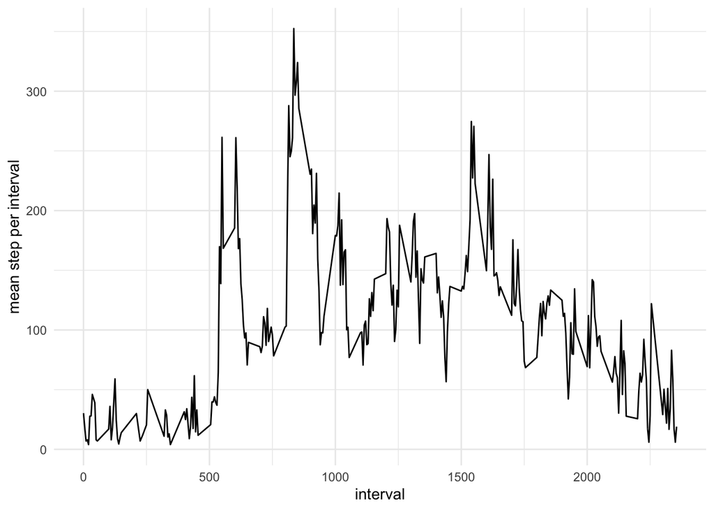

```r
# plot
as31p <-
    ggplot(as31d,aes(x=interval,y=mean.step.interval)) +
    geom_line() +

    labs(
        y="mean step per interval"
    ) +
    theme_minimal()

print(as31p)
```

2. Which 5-minute interval, on average across all the days in the dataset, contains the maximum number of steps?

```r
# data cleaning prep
# average steps per days
as32d <-
    df %>%
    filter(!is.na(steps)) %>%
    filter(steps>0) %>%
    group_by(interval) %>%
    summarise(avg.interval=mean(steps)) %>%
    ungroup() %>%
    filter(avg.interval==max(avg.interval))
```

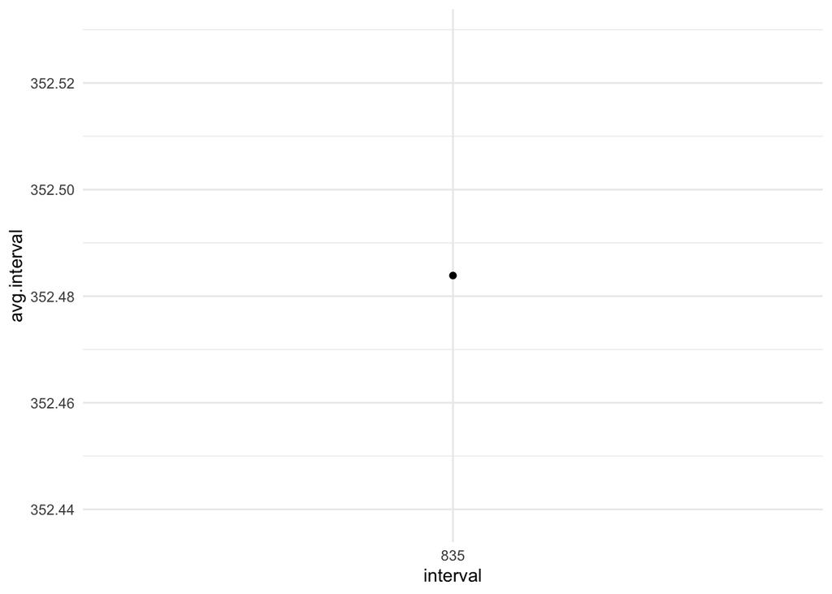

```r
# plot
as32p <-
    ggplot(as32d,aes(x=as.character(interval),y=avg.interval)) +
    geom_point() +
    labs(
        x="interval"
    )+
    theme_minimal()

print(as32p)
```

### 4.Imputing missing values

Note that there are a number of days/intervals where there are missing values (coded as `NA`). The presence of missing days may introduce bias into some calculations or summaries of the data.

1. Calculate and report the total number of missing values in the dataset (i.e. the total number of rows with `NA`s)

```r
as41d <-
    df %>%
    # filter_if(is.numeric,anyNA) %>%
    # filter(is.na(steps)) %>% # 2304
    # filter(is.na(steps)|is.na(interval)) %>% # 2304
    filter(is.na(steps)|is.na(interval)|is.na(date)) %>% #2304
    nrow()

print(paste("The total number of missing values in the dataset is ",as41d))
```

```
## [1] "The total number of missing values in the dataset is  2304"
```

2. Devise a strategy for filling in all of the missing values in the dataset. The strategy does not need to be sophisticated. For example, you could use the mean/median for that day, or the mean for that 5-minute interval, etc.

```r
# Calculate the median steps for that day
medianDay <- df %>%
    filter(!is.na(steps)) %>%
    filter(steps>0) %>%
    group_by(date) %>%
    summarise(step.median.day=median(steps)) %>%
    ungroup()
```

```r
# Calculate the mean steps for that 5-minute interval
meanInterval <- df %>%
    filter(!is.na(steps)) %>%
    filter(steps>0) %>%
    group_by(interval) %>%
    summarise(step.mean.interval=mean(steps)) %>%
    ungroup()
```

3. Create a new dataset that is equal to the original dataset but with the missing data filled in.

```r
# new dataset with 3 fill strategy.

as43d <- df %>%
    # Firstly, the missing data filled with step.median.day firstly,
    left_join(medianDay,by="date") %>%
    mutate(steps=if_else(is.na(steps),step.median.day,steps)) %>%
    select(date,interval,steps) %>%

    # Secondly, the missing data filled with step.median.interval secondly
    left_join(meanInterval,by="interval") %>%
    mutate(steps=if_else(is.na(steps),step.mean.interval,steps)) %>%
    select(date,interval,steps) %>%

    # Finally, the missing data filled with 0 finally
    mutate(steps=if_else(is.na(steps),0,steps))
```

4. Make a histogram of the total number of steps taken each day and Calculate and report the **mean** and **median** total number of steps taken per day. Do these values differ from the estimates from the first part of the assignment? What is the impact of imputing missing data on the estimates of the total daily number of steps?

```r
as44d <- as43d %>%
    group_by(date) %>%
    summarise(steps.total.day=sum(steps))
```

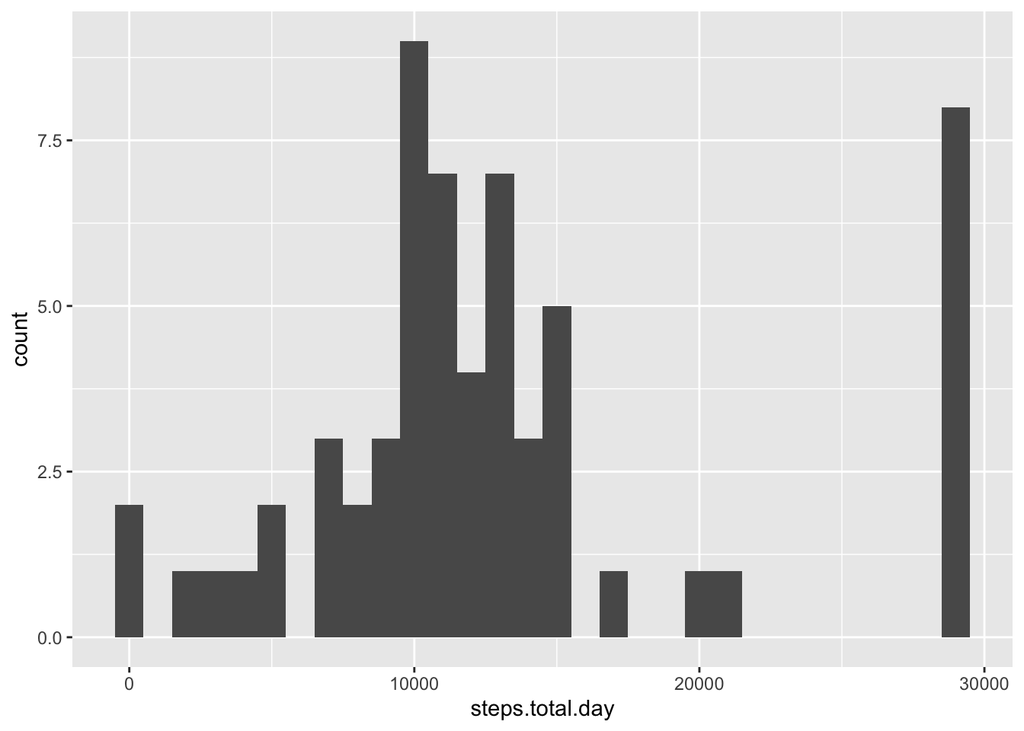

```r
as44g1 <- ggplot(as44d,aes(x=steps.total.day))+
    geom_histogram()

print(as44g1)
```

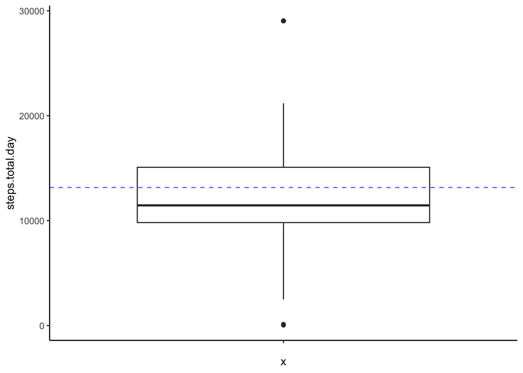

```r
# Show mean with blue dash line and median with black solide line in box
as44g2 <-
    ggplot(as44d,aes(x="",y=steps.total.day)) +
    geom_boxplot() +
    geom_hline(yintercept=mean(as44d$steps.total.day),
               color="blue",
               linetype="dashed",
               linewidth=.5,
               alpha=0.618,
               ) +
    theme_classic()

print(as44g2)
```

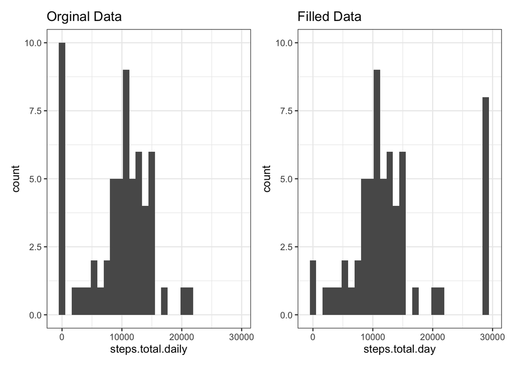

```r
# Do these values differ from the estimates from the first part of the assignment?
library(patchwork)
as22g +
    scale_x_continuous(limits = c(-1000, 30000)) +
    scale_y_continuous(limits = c(0, 10)) +
    labs(title = "Orginal Data") +
    theme_bw() |
as44g1 +
    scale_x_continuous(limits = c(-1000, 30000)) +
    scale_y_continuous(limits = c(0, 10)) +
    labs(title = "Filled Data") +
    theme_bw()
```

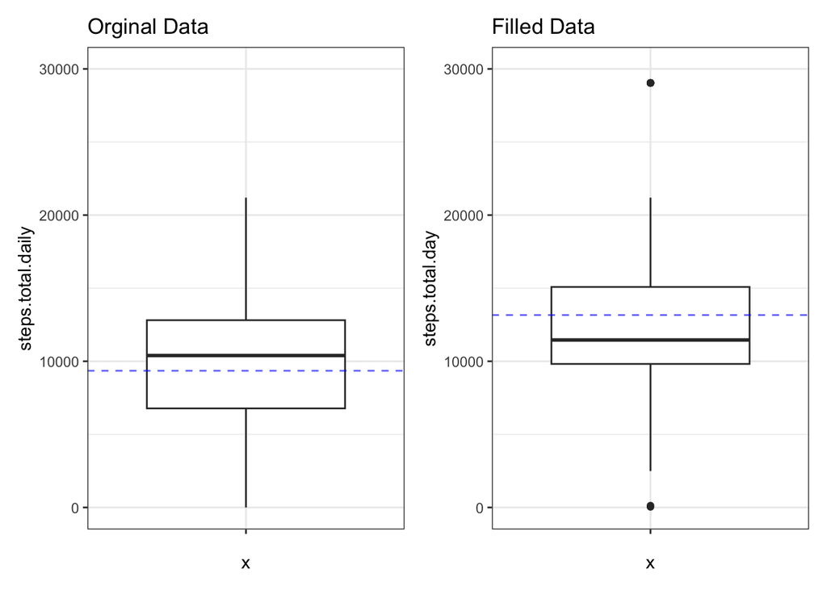

```r
# What is the impact of imputing missing data on the estimates of the total daily number of steps?

library(patchwork)
as23g +
    scale_y_continuous(limits = c(0, 30000)) +
    labs(title = "Orginal Data") +
    theme_bw() |
as44g2 +
    scale_y_continuous(limits = c(0, 30000)) +
    labs(title = "Filled Data") +
    theme_bw()
```

### 5.Are there differences in activity patterns between weekdays and weekends?

1. Create a new factor variable in the dataset with two levels – “weekday” and “weekend” indicating whether a given date is a weekday or weekend day.

```r
as51d <- df %>%
    mutate(weekday = wday(date,week_start = getOption("lubridate.week.start", 1))) %>%
    mutate(daytype = factor(if_else(weekday %in% c(6,7),"weekend","weekday"))) %>%
    select(daytype,date,interval,steps)
```

```r
as52d <- as51d %>%
    group_by(daytype,interval) %>%
    summarise(steps.total.interval=sum(steps,na.rm = TRUE))
```

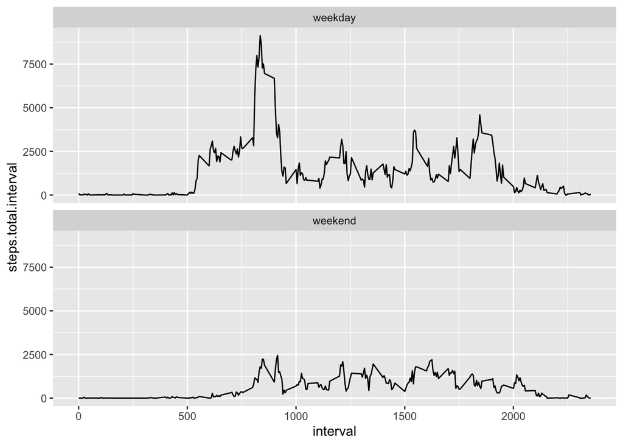

```r
as52g <-
    ggplot(as52d,aes(x=interval,y=steps.total.interval)) +
    geom_line() +
    facet_wrap(~ daytype,scales = "fixed",nrow = 2 )

as52g
```

## Submitting the Assignment